# Diamonds Exercise II

Jonathan Morken

February 20, 2016

The following is my set of notes/results from performing the second Udacity Diamonds problem set.

### Section One - Create a scatterplot of price vs. x using ggplot syntax:

Basic Plot:

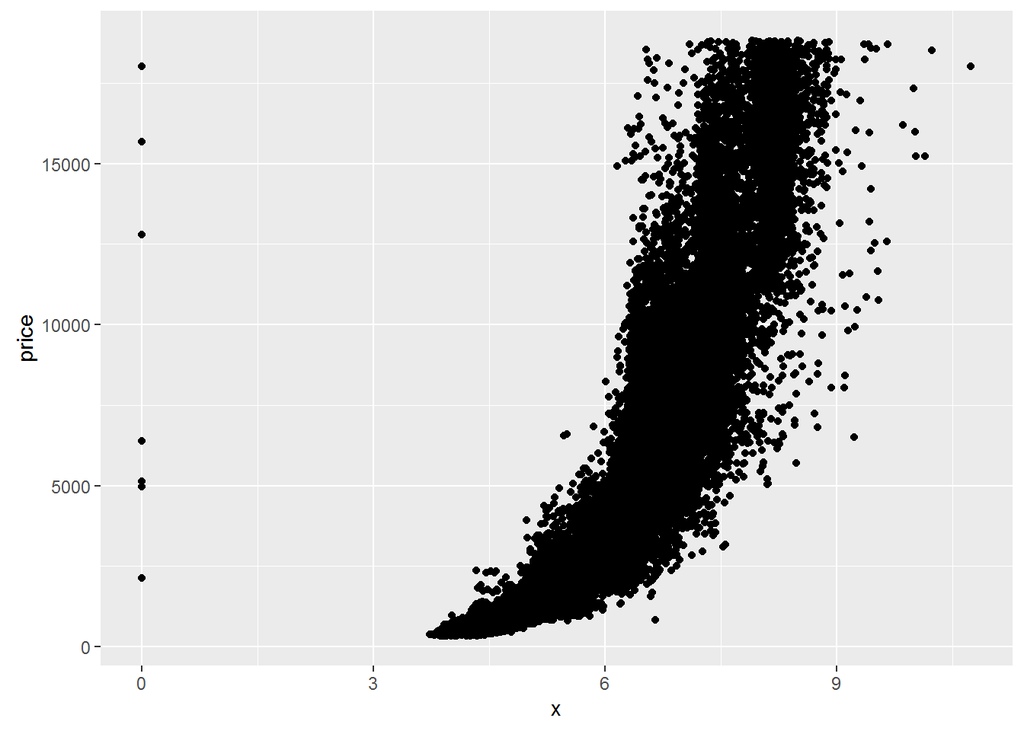

#### Observations

The overall shape is similar to that of an increasing exponential function. Transparency should be employed to better illustrate concentration.

#### Answers to section questions

What are the correlations of the following:  
(1) price to x: 0.8844352  
(2) price to y: 0.8654209  
(3) price to z: 0.8612494

### Section Two - Create a simple scatterplot of price vs. depth:

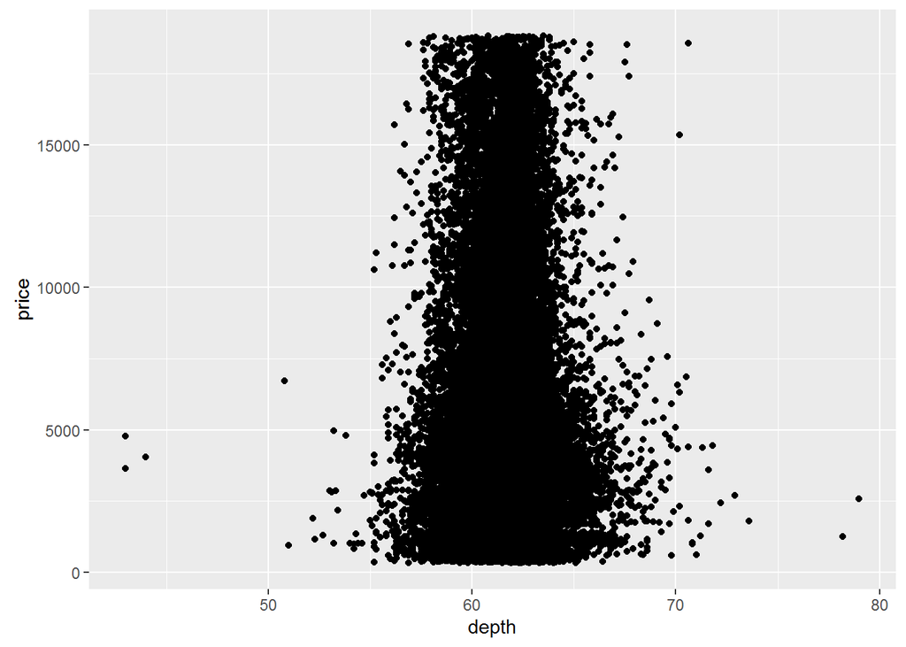

#### Part Two - Change the code to make the transparency of the points to be 1/100 of what they are now and mark the x-axis every 2 units.

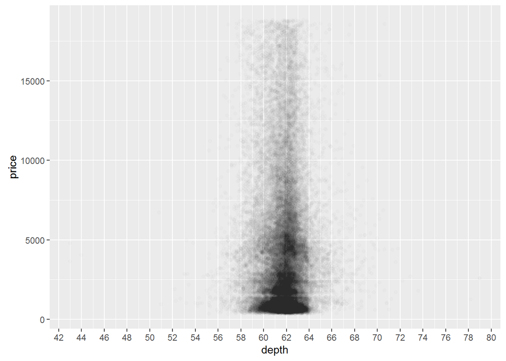

```r
g2 + geom_point(alpha = 1/100) +
  scale_x_continuous(breaks = seq(40,80,2))
```

### Section Three - Create a scatterplot of price vs carat and omit the top 1% of price and carat values.

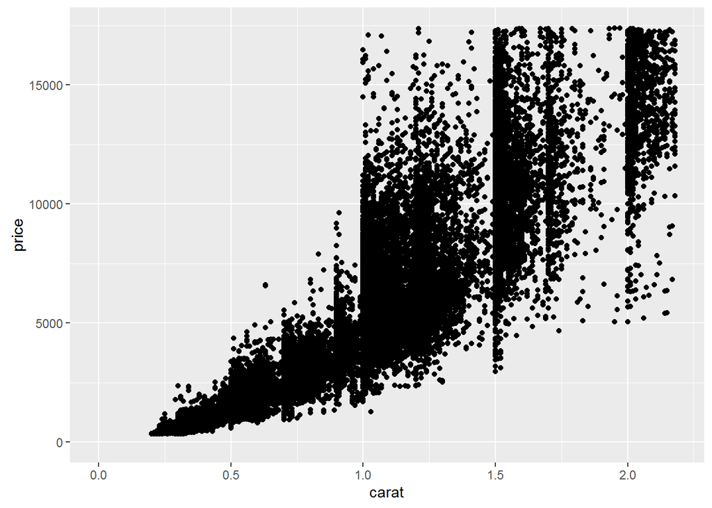

#### Part Two - Create a scatterplot of price vs. volume (x * y * z). Create a new variable for volume in the diamonds data frame. This will be useful in a later exercise. Don’t make any adjustments to the plot just yet.

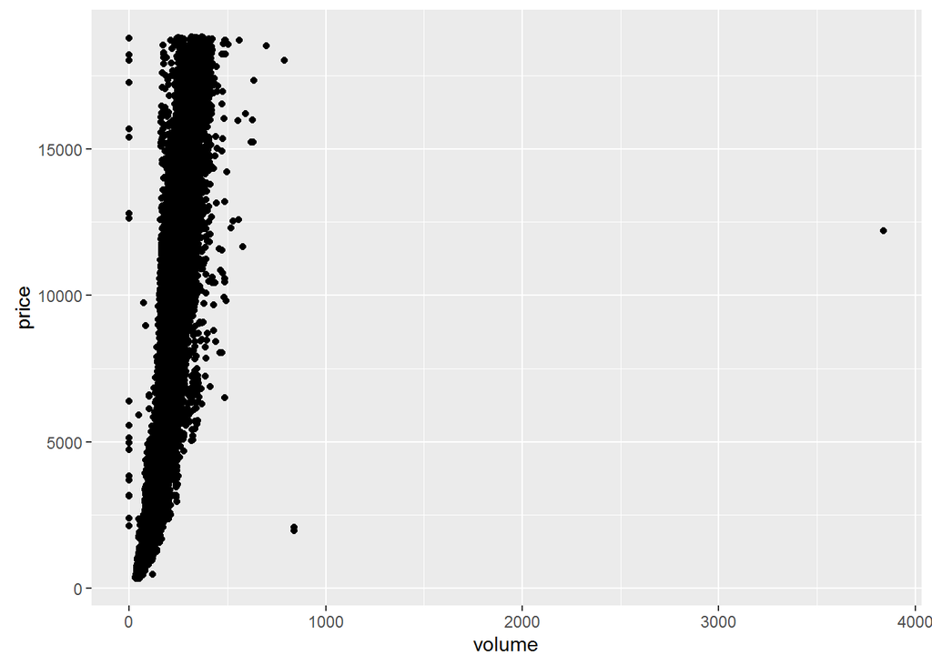

#### Part Three - Create data frame with volume > 0 & < 800 then provide observations on the above graph and answers to questions:

It is a very steep, increasing curve that is over-plotted. There also seem to be some erroneous outliers, that should likely be ignored. There are also 20 diamonds with 0 volume! Also, including only diamonds with volume >0 and <800, the correlation of price to volume is equal to 0.9235455

### Section Four - Adjust the transparency of the points and add a linear model to the plot.

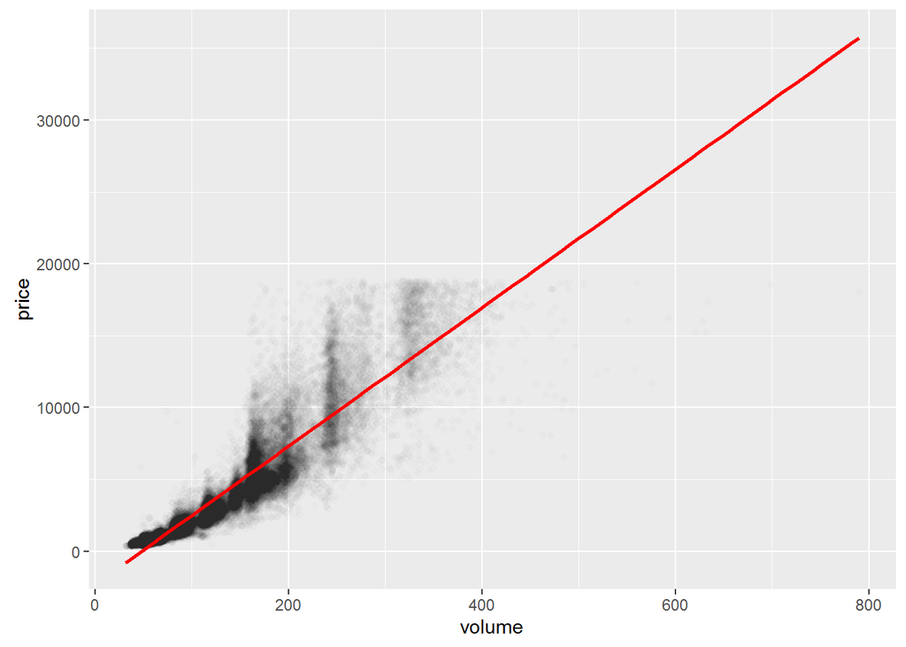

####Answers to questions I believe their are better models than the linear one presented above to predict price based on volume. For instance, a quadratic model like y= x + I(x^2) would likely be a closer fit. That said, both lose effectiveness above the 150 mark for volume.

### Section Three - See instructions below:

#### Part one

Use the function dplyr package to create a new data frame containing info on diamonds by clarity. Name the data frame diamondsByClarity. The data frame should contain the following variables in this order: (1) mean_price (2) median_price (3) min_price (4) max_price (5) n where n is the number of diamonds in each level of clarity.

```
## Source: local data frame [8 x 6]
##
##   clarity mean_price median_price min_price max_price     n
##    (fctr)      (dbl)        (dbl)     (int)     (int) (int)
## 1      I1   3924.169         3344       345     18531   741
## 2     SI2   5063.029         4072       326     18804  9194
## 3     SI1   3996.001         2822       326     18818 13065
## 4     VS2   3924.989         2054       334     18823 12258
## 5     VS1   3839.455         2005       327     18795  8171
## 6    VVS2   3283.737         1311       336     18768  5066
## 7    VVS1   2523.115         1093       336     18777  3655
## 8      IF   2864.839         1080       369     18806  1790
```

#### Part Two - Use summary data frames with the mean price by clarity and color to write additional code to create two bar plots on one output image using the grid.arrange() function from the package gridExtra.

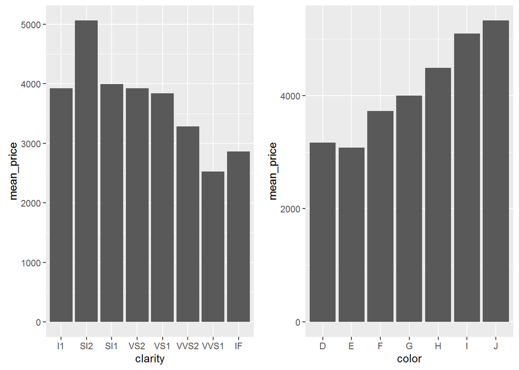

####Observations These aren’t behaving as I would have expected.  
Clarity: Price doesn’t follow quality of clarity. Color: Mean price increases as as color quality decreases.